# Conventional ML Algorithms

**Scikit-Learn** is a powerful and user-friendly machine learning library in Python, which facilitate multiple Conventional ML Algorithms. It provides a wide range of tools and algorithms for tasks like **classification, regression, clustering**, and more. With its simple and consistent API, Scikit-Learn is a popular choice for both beginners and experienced machine learning practitioners.

```python
!pip install numpy
```

```python
!pip install scikit-learn
```

```python
!pip install seaborn
```

```
  Obtaining dependency information for seaborn from https://files.pythonhosted.org/packages/7b/e5/83fcd7e9db036c179e0352bfcd20f81d728197a16f883e7b90307a88e65e/seaborn-0.13.0-py3-none-any.whl.metadata
  Using cached seaborn-0.13.0-py3-none-any.whl.metadata (5.3 kB)
Using cached seaborn-0.13.0-py3-none-any.whl (294 kB)
```

```python
!pip install matplotlib
```

```python
!pip install pylab
```

```
ERROR: Could not find a version that satisfies the requirement pylab (from versions: none)
ERROR: No matching distribution found for pylab
```

```python
%matplotlib inline
import numpy as np
import matplotlib.pyplot as plt
import seaborn;
from sklearn.linear_model import LinearRegression
from scipy import stats
import pylab as pl
seaborn.set()
```

## Machine Learning Models Cheat Sheet

```python
from IPython.display import Image
Image("http://scikit-learn.org/dev/_static/ml_map.png", width=800)
```

## Estimators

Given a scikit-learn *estimator* object named `model`, the following methods are available:

- Available in **all Estimators**
  - `model.fit()` : fit training data. For supervised learning applications, this accepts two arguments: the data `X` and the labels `y` (e.g. `model.fit(X, y)`). For unsupervised learning applications, this accepts only a single argument, the data `X` (e.g. `model.fit(X)`).
- Available in **supervised estimators**
  - `model.predict()` : given a trained model, predict the label of a new set of data. This method accepts one argument, the new data `X_new` (e.g. `model.predict(X_new)`), and returns the learned label for each object in the array.
  - `model.predict_proba()` : For classification problems, some estimators also provide this method, which returns the probability that a new observation has each categorical label. In this case, the label with the highest probability is returned by `model.predict()`.
  - `model.score()` : for classification or regression problems, most (all?) estimators implement a score method. Scores are between 0 and 1, with a larger score indicating a better fit.
- Available in **unsupervised estimators**
  - `model.predict()` : predict labels in clustering algorithms.
  - `model.transform()` : given an unsupervised model, transform new data into the new basis. This also accepts one argument `X_new`, and returns the new representation of the data based on the unsupervised model.
  - `model.fit_transform()` : some estimators implement this method, which more efficiently performs a fit and a transform on the same input data.

## K-Nearest Neighbors Classification with Iris Dataset

The K-Nearest Neighbors (KNN) algorithm is a method used for algorithm used for **classification** or for **regression**. In both cases, the input consists of the k closest training examples in the feature space. Given a new, unknown observation, look up which points have the closest features and assign the predominant class.

This data sets consists of 3 different types of irises’ (Setosa, Versicolour, and Virginica) petal and sepal length, stored in a 150x4 numpy.ndarray The rows being the samples and the columns being: Sepal Length, Sepal Width, Petal Length and Petal Width.

[figure not shown]

```python
from sklearn.datasets import load_iris
iris = load_iris()

n_samples, n_features = iris.data.shape
print(iris.keys())
print((n_samples, n_features))
print(iris.data.shape)
print(iris.target.shape)
print(iris.target_names)
print(iris.feature_names)
```

```
dict_keys(['data', 'target', 'frame', 'target_names', 'DESCR', 'feature_names', 'filename', 'data_module'])
(150, 4)
(150, 4)
(150,)
['setosa' 'versicolor' 'virginica']
['sepal length (cm)', 'sepal width (cm)', 'petal length (cm)', 'petal width (cm)']
```

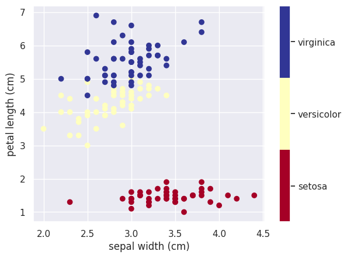

```python
import numpy as np
import matplotlib.pyplot as plt

# 'sepal width (cm)'
x_index = 1
# 'petal length (cm)'
y_index = 2

# this formatter will label the colorbar with the correct target names
formatter = plt.FuncFormatter(lambda i, *args: iris.target_names[int(i)])

plt.scatter(iris.data[:, x_index], iris.data[:, y_index],
            c=iris.target, cmap=plt.cm.get_cmap('RdYlBu', 3))
plt.colorbar(ticks=[0, 1, 2], format=formatter)
plt.clim(-0.5, 2.5)
plt.xlabel(iris.feature_names[x_index])
plt.ylabel(iris.feature_names[y_index]);
```

```python
from sklearn import neighbors, datasets

iris = datasets.load_iris()
X, y = iris.data, iris.target

# create the model
knn = neighbors.KNeighborsClassifier(n_neighbors=5, weights='uniform')

# fit the model
knn.fit(X, y)
```

```
KNeighborsClassifier()
```

```python
# What kind of iris has 3cm x 5cm sepal and 4cm x 2cm petal?
X_pred = [3, 5, 4, 2]
result = knn.predict([X_pred, ])

print(iris.target_names[result])
print(iris.target_names)
print(knn.predict_proba([X_pred, ]))
```

```
['versicolor']
['setosa' 'versicolor' 'virginica']
[[0.  0.8 0.2]]
```

## Scikit Learn : Regression with Diabetes Dataset

In this section, we will explore regression using the Scikit Learn library. We'll be using the diabetes dataset to predict diabetes progression. Regression is a type of supervised learning where the goal is to predict a continuous target variable.

### Dataset Description

The diabetes dataset contains ten baseline variables (age, sex, body mass index, average blood pressure, and six blood serum measurements) obtained for diabetes patients. The target variable is a quantitative measure of disease progression one year after baseline.

```python
import matplotlib.pyplot as plt
import numpy as np

from sklearn import datasets, linear_model
from sklearn.metrics import mean_squared_error, r2_score
```

```python
# Load the diabetes dataset
diabetes_X, diabetes_y = datasets.load_diabetes(return_X_y=True)

# Use only one feature
diabetes_X = diabetes_X[:, np.newaxis, 2]

# Split the data into training/testing sets
diabetes_X_train = diabetes_X[:-20]
diabetes_X_test = diabetes_X[-20:]

# Split the targets into training/testing sets
diabetes_y_train = diabetes_y[:-20]
diabetes_y_test = diabetes_y[-20:]
```

```python
# Create linear regression object
regr = linear_model.LinearRegression()

# Train the model using the training sets
regr.fit(diabetes_X_train, diabetes_y_train)
```

```
LinearRegression()
```

```python
# Make predictions using the testing set
diabetes_y_pred = regr.predict(diabetes_X_test)

# The coefficients
print("Coefficients: \n", regr.coef_)
# The mean squared error
print("Mean squared error: %.2f" % mean_squared_error(diabetes_y_test, diabetes_y_pred))
# The coefficient of determination: 1 is perfect prediction
print("Coefficient of determination: %.2f" % r2_score(diabetes_y_test, diabetes_y_pred))
```

```
Coefficients:
 [938.23786125]
Mean squared error: 2548.07
Coefficient of determination: 0.47
```

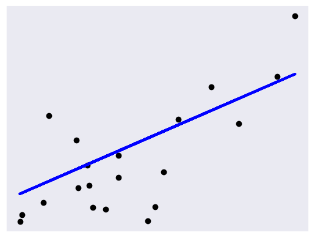

```python
# Plot outputs
plt.scatter(diabetes_X_test, diabetes_y_test, color="black")
plt.plot(diabetes_X_test, diabetes_y_pred, color="blue", linewidth=3)

plt.xticks(())
plt.yticks(())

plt.show()
```

## Scikit Learn for Computer Vision

```python
import numpy as np
import matplotlib.pyplot as plt
from sklearn import datasets
from sklearn.model_selection import train_test_split
from sklearn.linear_model import LogisticRegression
from sklearn.metrics import classification_report, accuracy_score
```

```python
# Load the digits dataset
digits = datasets.load_digits()

# Create X (features) and y (target)
X = digits.images
y = digits.target
```

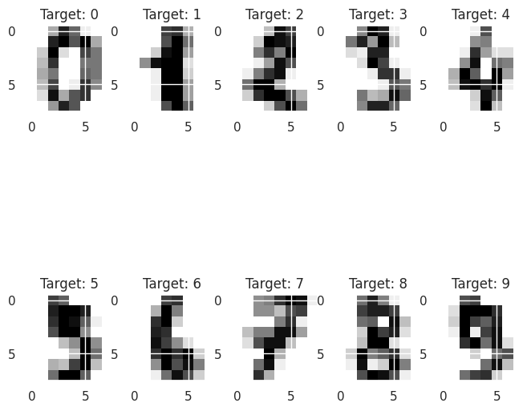

```python
# Display some sample images
plt.figure(figsize=(8, 8))
for i in range(10):
    plt.subplot(2, 5, i + 1)
    plt.imshow(X[i], cmap=plt.cm.gray_r, interpolation='nearest')
    plt.title(f'Target: {y[i]}')
plt.show()
```

```python
# Flatten the images
X = X.reshape((len(X), -1))
# Split Data into Training and Testing Sets
X_train, X_test, y_train, y_test = train_test_split(X, y, test_size=0.2, random_state=42)
```

```python
# Initialize and train the Logistic Regression model
model = LogisticRegression(max_iter=10000)
# Training
model.fit(X_train, y_train)
```

```
LogisticRegression(max_iter=10000)
```

```python
# Predict on test set
y_pred = model.predict(X_test)

# Calculate accuracy
accuracy = accuracy_score(y_test, y_pred)
print(f'Accuracy: {accuracy}')
```

```
Accuracy: 0.9722222222222222
```

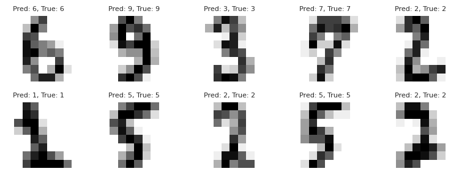

```python
# Display some predictions
plt.figure(figsize=(8, 3))
for i in range(10):
    plt.subplot(2, 5, i + 1)
    plt.imshow(X_test[i].reshape(8,8), cmap=plt.cm.gray_r, interpolation='nearest')
    plt.title(f'Pred: {y_pred[i]}, True: {y_test[i]}', fontsize=8)
    plt.axis('off')
plt.tight_layout()
plt.show()
```

## Text Classification

```python
from sklearn.datasets import fetch_20newsgroups
from sklearn.feature_extraction.text import TfidfVectorizer
from sklearn.model_selection import train_test_split
from sklearn.naive_bayes import MultinomialNB
from sklearn.metrics import classification_report, accuracy_score
```

```python
# Load the 20 newsgroups dataset
newsgroups = fetch_20newsgroups(subset='all')

# Explore the target categories
categories = newsgroups.target_names
print(f'Target Categories: {categories}')
```

```
Target Categories: ['alt.atheism', 'comp.graphics', 'comp.os.ms-windows.misc', 'comp.sys.ibm.pc.hardware', 'comp.sys.mac.hardware', 'comp.windows.x', 'misc.forsale', 'rec.autos', 'rec.motorcycles', 'rec.sport.baseball', 'rec.sport.hockey', 'sci.crypt', 'sci.electronics', 'sci.med', 'sci.space', 'soc…
```

```python
# Convert text data to TF-IDF features
tfidf_vectorizer = TfidfVectorizer(max_features=10000, stop_words='english')
X = tfidf_vectorizer.fit_transform(newsgroups.data)
y = newsgroups.target
```

```python
# Splittin the Data
X_train, X_test, y_train, y_test = train_test_split(X, y, test_size=0.2, random_state=42)
```

```python
# Initialize and train the Multinomial Naive Bayes classifier
nb_classifier = MultinomialNB()
nb_classifier.fit(X_train, y_train)
```

```
MultinomialNB()
```

```python
# Predict on test set
y_pred = nb_classifier.predict(X_test)

# Calculate accuracy
accuracy = accuracy_score(y_test, y_pred)
print(f'Accuracy: {accuracy}')

# Generate classification report
report = classification_report(y_test, y_pred, target_names=categories)
print(f'Classification Report:\n{report}')
```

```
Accuracy: 0.870291777188329
Classification Report:
                          precision    recall  f1-score   support

             alt.atheism       0.83      0.88      0.86       151
           comp.graphics       0.77      0.84      0.80       202
 comp.os.ms-windows.misc       0.81      0.82      0.81       195
comp.sys.ibm.pc.hardware       0.64      0.80      0.71       183
   comp.sys.mac.hardware       0.90      0.85      0.88       205
          comp.windows.x       0.90      0.85      0.87       215
            misc.forsale       0.85      0.76      0.81       193
               rec.autos       0.91      0.94      0.92       196
         rec.motorcycles       0.89      0.94      0.92       168
      rec.sport.baseball       0.97      0.94      0.95       211
        rec.sport.hockey       0.90      0.97      0.94       198
               sci.crypt       0.95      0.95      0.95       201
         sci.electronics       0.92      0.77      0.84       202
                 sci.med       0.97      0.89      0.93       194
               sci.space       0.90      0.97      0.93       189
  soc.religion.christian       0.77      0.98      0.86       202
      talk.politics.guns       0.85      0.96      0.90       188
   talk.politics.mideast       0.95      0.98      0.97       182
      talk.politics.misc       0.96      0.79      0.87       159
      talk.religion.misc       0.92      0.36      0.52       136

                accuracy                           0.87      3770
               macro avg       0.88      0.86      0.86      3770
            weighted avg       0.88      0.87      0.87      3770
```

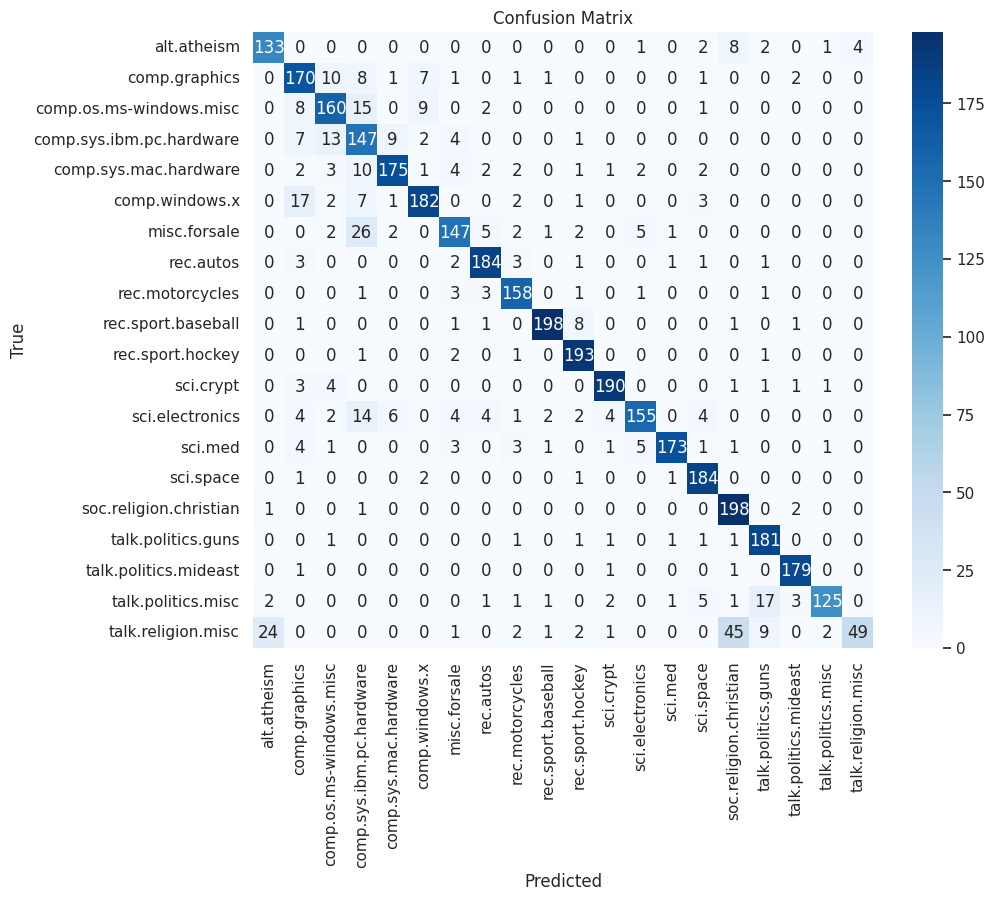

```python
# Confusion Matrix
from sklearn.metrics import confusion_matrix
import seaborn as sns

# Generate confusion matrix
cm = confusion_matrix(y_test, y_pred)

# Create a heatmap
plt.figure(figsize=(10, 8))
sns.heatmap(cm, annot=True, fmt='d', cmap='Blues', xticklabels=categories, yticklabels=categories)
plt.xlabel('Predicted')
plt.ylabel('True')
plt.title('Confusion Matrix')
plt.show()
```

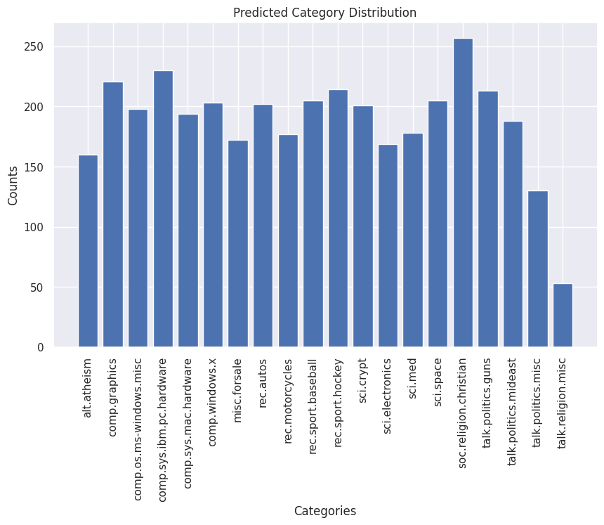

```python
# Category Distribution
plt.figure(figsize=(10, 6))
category_counts = np.bincount(y_pred)
plt.bar(categories, category_counts)
plt.xticks(rotation=90)
plt.xlabel('Categories')
plt.ylabel('Counts')
plt.title('Predicted Category Distribution')
plt.show()
```

## Support Vector Machines

[figure not shown]

```python
import numpy as np
import pandas as pd
import matplotlib.pyplot as plt
import seaborn as sb
from scipy.io import loadmat
%matplotlib inline
```

```python
raw_data = loadmat('inputs//svm_1.mat')
raw_data
```

[output not shown]

[output cut: 50 more lines]

[output not shown]

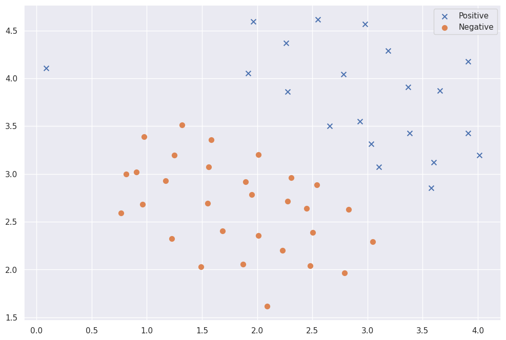

```python
data = pd.DataFrame(raw_data['X'], columns=['X1', 'X2'])
data['y'] = raw_data['y']

positive = data[data['y'].isin([1])]
negative = data[data['y'].isin([0])]

fig, ax = plt.subplots(figsize=(12,8))
ax.scatter(positive['X1'], positive['X2'], s=50, marker='x', label='Positive')
ax.scatter(negative['X1'], negative['X2'], s=50, marker='o', label='Negative')
ax.legend()
```

```python
from sklearn import svm
svc = svm.LinearSVC(C=1, loss='hinge', max_iter=1000)
svc
```

```
LinearSVC(C=1, loss='hinge')
```

```python
svc.fit(data[['X1', 'X2']], data['y'])
svc.score(data[['X1', 'X2']], data['y'])
```

```
0.9803921568627451
```

###### Let us increase the C

```python
svc2 = svm.LinearSVC(C=100, loss='hinge', max_iter=1000)
svc2.fit(data[['X1', 'X2']], data['y'])
svc2.score(data[['X1', 'X2']], data['y'])
```

```
1.0
```

This time we got a perfect classification of the training data, however by increasing the value of C we've created a decision boundary that is no longer a natural fit for the data. We can visualize this by looking at the confidence level for each class prediction, which is a function of the point's distance from the hyperplane.

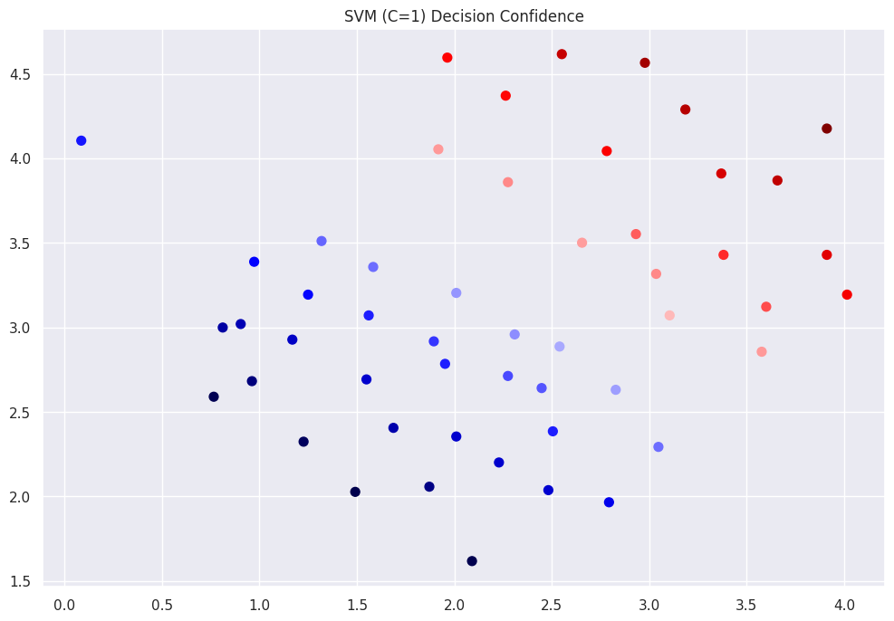

```python
data['SVM 1 Confidence'] = svc.decision_function(data[['X1', 'X2']])
fig, ax = plt.subplots(figsize=(12,8))
ax.scatter(data['X1'], data['X2'], s=50, c=data['SVM 1 Confidence'], cmap='seismic')
ax.set_title('SVM (C=1) Decision Confidence')
```

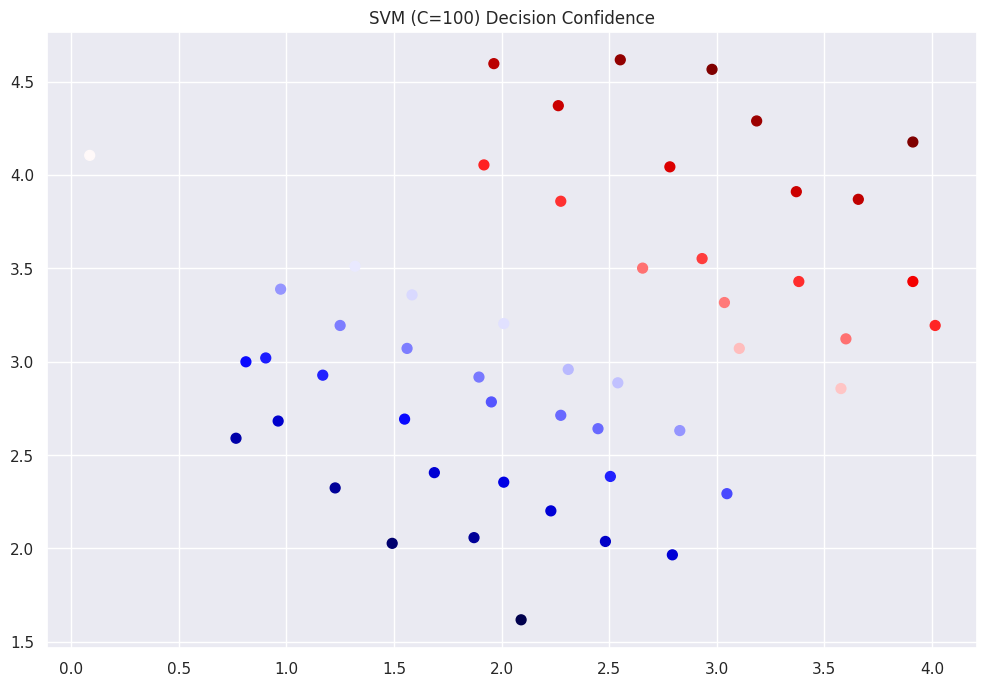

```python
data['SVM 2 Confidence'] = svc2.decision_function(data[['X1', 'X2']])

fig, ax = plt.subplots(figsize=(12,8))
ax.scatter(data['X1'], data['X2'], s=50, c=data['SVM 2 Confidence'], cmap='seismic')
ax.set_title('SVM (C=100) Decision Confidence')
```

The difference is a bit subtle but look at the color of the points near the boundary.

#### linear SVM to one that's capable of non-linear classification using kernels

[figure not shown]

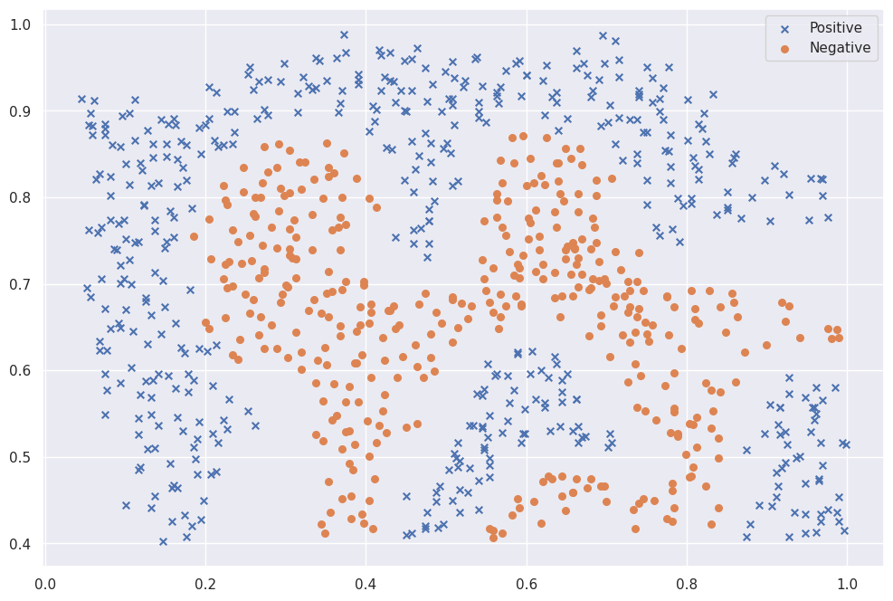

```python
raw_data = loadmat('inputs/svm_2.mat')

data = pd.DataFrame(raw_data['X'], columns=['X1', 'X2'])
data['y'] = raw_data['y']

positive = data[data['y'].isin([1])]
negative = data[data['y'].isin([0])]

fig, ax = plt.subplots(figsize=(12,8))
ax.scatter(positive['X1'], positive['X2'], s=30, marker='x', label='Positive')
ax.scatter(negative['X1'], negative['X2'], s=30, marker='o', label='Negative')
ax.legend()
```

### With linear kernel

```python
svc = svm.SVC(C=100, gamma=10, kernel="linear", probability=True)
svc
```

```
SVC(C=100, gamma=10, kernel='linear', probability=True)
```

```python
svc.fit(data[['X1', 'X2']], data['y'])
svc.score(data[['X1', 'X2']], data['y'])
```

```
0.5701042873696408
```

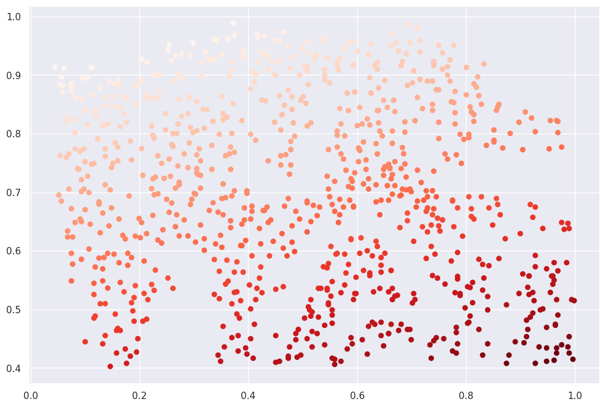

```python
data['Probability'] = svc.predict_proba(data[['X1', 'X2']])[:,0]

fig, ax = plt.subplots(figsize=(12,8))
ax.scatter(data['X1'], data['X2'], s=30, c=data['Probability'], cmap='Reds')
```

### With non-linear kernel

```python
svc = svm.SVC(C=100, gamma=10, kernel="rbf", probability=True)
svc
```

```
SVC(C=100, gamma=10, probability=True)
```

```python
svc.fit(data[['X1', 'X2']], data['y'])
svc.score(data[['X1', 'X2']], data['y'])
```

```
0.9698725376593279
```

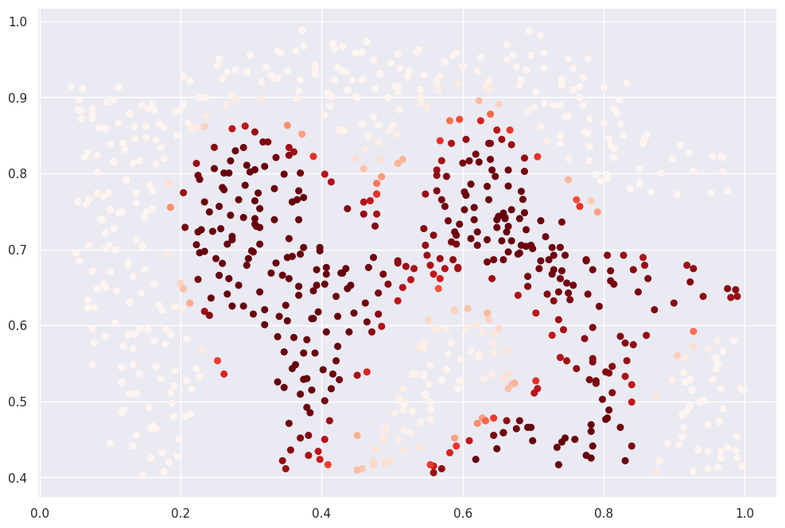

```python
data['Probability'] = svc.predict_proba(data[['X1', 'X2']])[:,0]

fig, ax = plt.subplots(figsize=(12,8))
ax.scatter(data['X1'], data['X2'], s=30, c=data['Probability'], cmap='Reds')
```

```python
svc = svm.SVC(C=100, gamma=10, kernel="poly", probability=True)
svc
```

```
SVC(C=100, gamma=10, kernel='poly', probability=True)
```

```python
svc.fit(data[['X1', 'X2']], data['y'])
svc.score(data[['X1', 'X2']], data['y'])
```

```
0.7137891077636153
```

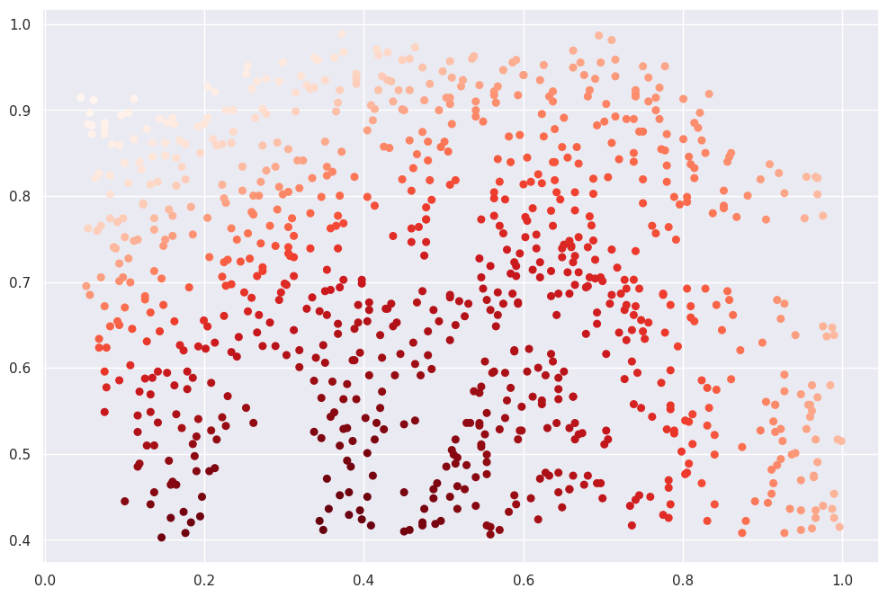

```python
data['Probability'] = svc.predict_proba(data[['X1', 'X2']])[:,0]

fig, ax = plt.subplots(figsize=(12,8))
ax.scatter(data['X1'], data['X2'], s=30, c=data['Probability'], cmap='Reds')
```